# Course Policies and Expectations

# Shadow Syllabus

Really, all I *want* to write here can be found in Sonya Huber’s [Shadow Syllabus](https://sonyahuber.com/2014/08/20/shadow-syllabus/amp/). There is a lot of truth in this list for your college careers and beyond. Read it and believe it.

# Required Texts

Most of the texts we will use in this class are freely available online, or in [the course packet](https://github.com/rccordell/f17rwda/blob/master/data/rwda-coursepacket.zip) (I will give you the password for this zip file in class). There are just a few you’ll need to buy (depending on what you choose as your second game in our final unit on “Play”). *Ready Player One* can be found at the Northeastern University Bookstore or purchased from any bookstore of your choosing, IRL or online. How you play *Portal* will depend a bit on whether you need to play on your computer, or if you have a console for gaming. It doesn’t matter to me where you play it, but find the game as soon as possible. If you have trouble finding it, let me know and I’ll help out.

Required:

Recommended:

- Giorgia Lupi and Stefanie Posavec, [*Dear Data*](http://www.dear-data.com/)

[figure not shown]

*[“Portal” by Sir Mildred Pierce](https://flic.kr/p/6iaE1y)*

# Communication

The best way to get in touch with me is to visit during my office hours. If you’re unsure about our readings, struggling with an assignment, or just want to talk, please visit. During the Fall 2017 semester, I will be in my office (Nightingale 415) on Mondays from 3-4:30pm and Wednesdays from 11am-noon. I’m also happy to make appointments at other times—just email me with **at least three possible meeting times** for me to choose among. I can schedule in person or virtual meetings.

The next best way to get in touch with me is by sending me an email. When you write to me: consider your tone and your audience. An email to your professor shouldn’t read the same as your emails to friends. For help, see [this guide to emailing your professors](https://medium.com/@lportwoodstacer/how-to-email-your-professor-without-being-annoying-af-cf64ae0e4087). I will respond to an email within 48 hours. Often I will respond more quickly, but you should not send me an urgent email, for example, the night before an assignment is due. If for some reason I have not responded to your email within two days, please do follow up—my delay is likely inadvertent and I will welcome a reminder.

# Participation

This course relies on active, engaged participation in class activities and discussions. There will be few lectures and we will not be building toward an exam. Instead, we will work together to build our facilities for thinking critically literature, new media, and technology. You should come to every class having read all of the required reading, watched the required videos, played the required games, and so forth. You should enter the classroom prepared to discuss these materials with colleagues and complete both individual and group [in-class assignments](http://f17rwda.ryancordell.org/assignments/in-class).

I will not explicitly grade participation in this course (i.e. “participation = 20% of final grade”), but I will take account of your reading and course engagement through our in-class work, discussions, and related activities. In-class work will regularly be graded, while other contributions can influence that grade (see “Participation Bonus” below). There are many ways to participate in a college class. Just a few of the most valuable contributions are:

1. Raising ideas from our assigned materials for class discussion, including directing our attention to specific moments you found evocative, inspiring, infuriating, or otherwise salient;
2. Asking questions about materials or ideas you found puzzling or difficult (I cannot overstate how valuable good questions are to a thriving class, and how desperately I wish more students were courageous in asking them);
3. Sending pertinent materials discovered outside of class to the course email list, or bringing them to our attention during discussion;
4. Assisting classmates with lab assignments or other in-class work amenable to cooperation;
5. Visiting during office hours to extend course conversations around subjects or questions you find particularly interesting.

Maintaining an active class conversation requires that the class be present, both physically and mentally. To that end: you may miss two classes without penalty. “Attendance” does not simply mean that your body can be found in proximity to those of your classmates. You must also be mentally present, which means you must:

1. Be awake and attentive to the conversation of the day;
2. Prepare assigned texts before class begins;
3. Bring your assigned texts to class. If we’re reading online articles, you should either bring a device on which to read them or print them and bring that hard copy. For some of our “texts” such as videogames this will be a bit harder to accomplish, but we will discuss what precisely to bring before those sessions;
4. *Bring your assigned texts to class!*
5. and, finally, **bring your assigned texts to class!!!** I mean it. Seriously. If you come to class without the day’s reading on hand, I reserve the right to count you absent.

If you fail to meet these requirements, I will consider you mentally absent, though you may be physically present.

**Please note**: I make no distinction between excused and unexcused absences, so use your allotted absences wisely. You may not miss two classes early in the semester and then petition for additional excused absences afterward. When you must miss class, it is your responsibility to find out what you missed and to make up any pertinent assignments. You may not make up quizzes or in-class work. If you take one of your excused absences, I simply will not grade any in-class work you missed. If you miss a lab due to an excused absence you should attempt to make up the work. Once beyond your allotted absences you will receive a zero for any in-class work or labs missed.

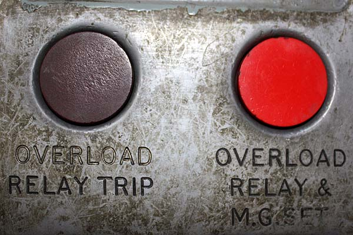

*[“Overload” by Sir Mildred Pierce](https://flic.kr/p/bp351N)*

## “Information Overload” Days

I do understand that the semester can get hectic. The reading load for this class is often challenging, and you must balance it with the work in your other classes. Most likely you will have days when you simply cannot—for whatever reason—complete the assigned reading. To that end, you may take *two “information overload” (IO) day* during the semester. On these days you will not be expected to contribute to class discussion and you will receive a pass on any in-class work (the work will be ungraded and not factored into your final “In-Class Work” grade). In order to take an IO day, you must follow these rules:

1. You must attend class, listen attentively to any lectures or class discussions, and take part in any activities or group work not dependent on the day’s reading. **Your IO days cannot be used as additional excused absences**.
2. You must inform me before the beginning of class that you are taking an IO day. You may not wait until I call on you or until you see day’s the in-class assignment. **I will deny any IO requests made during class**. To that end: take special care to be on time if you plan to request an IO day, as you won’t be allowed to request one if you arrive late.
3. You may not extend an IO day into another class session. If, for instance, you take an IO day during our first class on a novel, you will not then be excused from discussing the book during subsequent classes, unless you take your second IO day.
4. You may not take an IO day to avoid completing on a major assignment. IO days will excuse you from reading quizzes, group work, or reflections, but nothing of more serious import. If you are unsure whether an assignment is “major,” the syllabus is a good guide. If a given assignment has it’s own “assignment” page on the course website, it is a major assignment.

IO days are intended to help you manage the inevitable stresses of your individual semester. Use them wisely.

## Attendance and Participation Bonus

# Digital Etiquette

## In-class Devices

*Some of this section and much of the rubric below were inspired by and adapted from this [cell phone use rubric](http://www.zombiebased.com/edcourage/CellPhone%20Use%20Rubric.pdf) from Zombie Based Learning.*

This should go without saying, but let’s say it anyway: while in class, you should be focused on class. You may think that you are an excellent multi-tasker, but there is a [growing](https://www.psychologytoday.com/blog/the-power-prime/201103/technology-myth-multitasking) [body](https://www.forbes.com/sites/nickmorrison/2014/11/26/the-myth-of-multitasking-and-what-it-means-for-learning/print/) [of](https://www.psychologytoday.com/blog/creativity-without-borders/201405/the-myth-multitasking) [evidence](http://www.npr.org/sections/health-shots/2016/10/19/498450445/dont-look-now-how-your-devices-hurt-your-productivity) [that](http://time.com/money/3892931/stop-multitasking-and-start-singletasking/) [argues](http://time.com/4737286/multitasking-mental-health-stress-texting-depression/) multitasking [is](https://www.scientificamerican.com/podcast/episode/the-myth-of-multitasking-09-07-15/) [a](http://www.abc.net.au/radionational/programs/allinthemind/the-myth-of-multitasking/6743356) [myth](http://www.npr.org/2013/05/10/182861382/the-myth-of-multitasking): trying to do multiple things simultaneously means you do all those things worse than if you focused on them serially—the act of multitasking [literally drains your brain’s energy reserves](https://qz.com/722661/neuroscientists-say-multitasking-literally-drains-the-energy-reserves-of-your-brain/) In a discussion-focused class like this one, it’s usually pretty easy to tell when a student is checking in and and out of class an other on-screen activities.

In your professional lives, people will have their phones and other devices with them at their jobs, in meetings, at conferences, and so on. Adults do not have their devices taken away from them. They are expected to manage their own use.

You may have your phone and/or laptop on hand during class, but if so you should use them only for accessing our readings, class resources, or for finding outside materials pertinent to our discussions and activities. You should not use them to follow a game, message your friends, check your friends’ Tumblrs, commit (non course related) code to Github. Though it may seem unthinkable, your friends and family may actually survive three hours each week without direct updates as to your whereabouts and doings. They probably won’t call the police to report you missing. They will no doubt pine for your witty banter, but that longing will only make your 2:41pm updates all the sweeter each Monday, Wednesday, and Thursday this semester.

Periodically during the semester I may ask folks to put screens away. This means I want everyone—myself included—to focus attention on another aspect of class. In fact, it would be a very good idea to have a physical notebook available for classes when phones and laptops cannot be used.

## Device Use Rubric

The rubric below outlines my expectations for device use in this classroom. We can discuss these expectations in our first days together and edit them if the class agrees on amendments. I will not be recording marks for device use in every class. Instead, I will assess your use periodically and include these measures in my assessment of your class contributions.

[output not shown]

[figure not shown]

*[“Glitch” by 622](https://flic.kr/p/koRKuX)*

## Technical Snafus

This course will rely on access to computers, specific software, and the internet. **At some point during the semester you WILL have a problem with technology**: your laptop will crash, a file will become corrupted, a server will go down, a piece of software will not act as you expect it to, or something else will occur. These are facts of twenty-first-century life, not emergencies. To succeed in college and in your career you should develop work habits that take such snafus into account. Start assignments early and save often. [Always keep a backup copy of your work saved somewhere secure](https://www.dropbox.com/) (preferably off site). None of these unfortunate events should be considered emergencies: inkless printers, computer virus infections, lost flash drives, lost passwords, corrupted files, incompatible file formats. It is *entirely your responsibility* to take the proper steps to ensure your work will not be lost irretrievably; if one device or service isn’t working, find another that does. When problems arise in the software I have assigned for you to learn, we will work through those problems together and learn thereby. However, I will not grant you an extension based on problems you may be having with the specific devices or the internet services you happen to use.

# TRACE Evaluations

Students are expected to complete a TRACE (Teacher Rating and Course Evaluation) toward the end of the semester. I will set aside some time during a class period for students to complete their TRACEs.

# Academic Integrity

In this class you will abide by Northeastern University’s Academic Integrity Policy at all times:

> A commitment to the principles of academic integrity is essential to the mission of Northeatern University. The promotion of independent and original scholarship ensures that students derive the most from their educational experience and their pursuit of knowledge. Academic dishonesty violates the most fundamental values of an intellectual community and undermines the achievements of the entire University.

If you have any questions about what constitutes academic integrity in this class—particularly as the concept applies to digital course projects—please talk to me. We will also discuss the ethics of digital scholarship in class.

# Writing Center

The Northeastern University Writing Center is located in 412 Holmes Hall and in Snell Library (for current hours call 617-373-4549 or see http://www.northeastern.edu/english/writing-center/) and offers free and friendly help for any level writer, including help with reading complex texts, conceptualizing a writing project, refining your writing process (i.e., planning, researching, organization, drafting, revising, and editing), and using sources effectively. You can receive feedback face-to-face during regular hours or via email/online response. I strongly recommend that you make appointments to go over drafts of your work—including your digital work—before turning it in. Questions about the Writing Center can be directed to neuwritingcenter@gmail.com.